# What can an LLM contribute to qualitative interpretation?

## Ibrahim and Voyer make the interaction part of the method

[figure not shown]

**Examples:** deductive coding of Twitter bios and inductive analysis of etiquette texts.

**Argument:** prompts express researchers’ assumptions, while model responses can redirect subsequent analysis.

**Proposal:** technological reflexivity should cover model bias, researcher–algorithm interaction, evaluation, transparency, epistemic reflection, and ethics.

Ibrahim, E. I., and A. Voyer. (2026). “Qualitative Research with LLM Chatbots: Technological Reflexivity for Interpretative Technology.” *Qualitative Research* 26(1):133–159. https://doi.org/10.1177/14687941251390794.

## Their checklist specifies what reflexivity covers

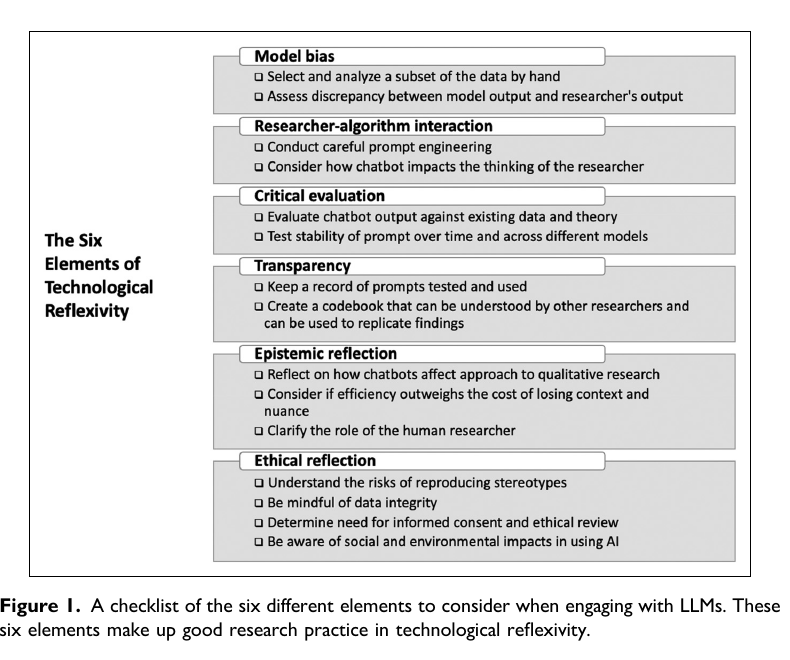

Ibrahim and Voyer (2026), Figure 1.

## They ask researchers to analyse the chat as a timeline

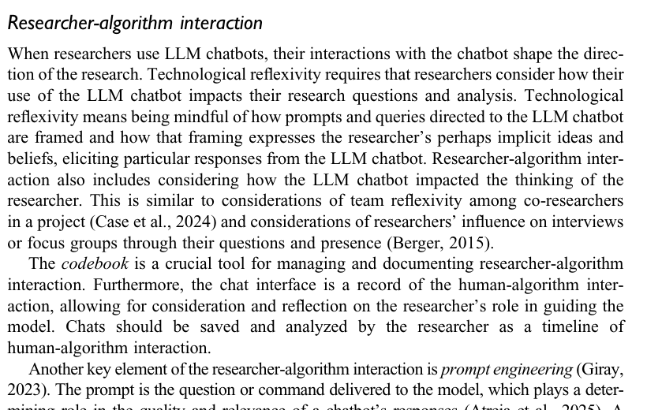

The prompt reflects the researcher’s definitions and assumptions.

The response may make some patterns easier to notice and others easier to ignore.

Saving the chat preserves the exchange. A researcher memo is still needed to explain how it affected the next analytic decision.

Ibrahim and Voyer (2026), pp. 142–143.

## Their first prompt exposed an unstated coding rule

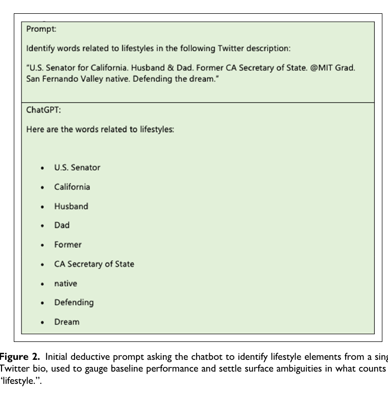

The model treated offices, locations, and status words as “lifestyle” because the researchers had not supplied their fuller definition.

Comparing the output with hand coding made the implicit rule visible.

The researchers then expanded the definition and updated the codebook.

Ibrahim and Voyer (2026), Figure 2 and accompanying text.

## Their inductive example uses a continuing chat

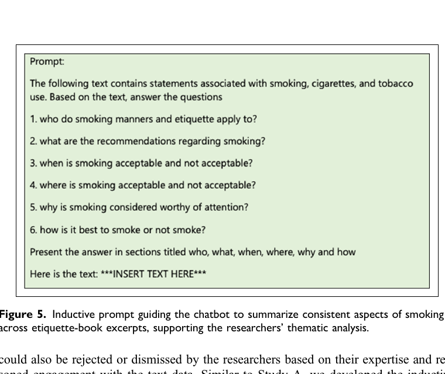

The model receives a substantive question and the relevant etiquette-book text.

Follow-up questions occur in the same chat, so earlier prompts and outputs remain part of the immediate context.

The researchers retain or reject suggestions using their own reading and expertise.

Ibrahim and Voyer (2026), Figure 5 and pp. 145–146.

## This is the interaction we will record in the example

**Before the model**

Researcher memo: practical help and political identity may remain separate.

**Model request**

Research question plus eight labelled excerpts.

**Model proposal**

Mutual aid transforms dependence into solidarity.

**Researcher response**

Check sources, inspect countercases, and revise the claim.

The research record should preserve all four stages, including what the researcher had already noticed.

## There are no settled standards for this work yet

**Tasks vary**

Studies use LLMs for retrieval, coding, theme proposals, quotation selection, and interpretation.

**Evidence varies**

Some compare with human coding; others document an iterative collaboration.

**Models change**

Access routes, context limits, and underlying models can change during a project.

This is a fast-moving methodological area. Researchers need to state exactly what the model did, what it saw, how output was checked, and which decisions remained human.

Than et al. (2025); Mehta et al. (2025); Ibrahim and Voyer (2026).

## After the break, we will follow one analysis record in Python

The code reproduces the same sequence: excerpts → model request → saved proposal → source check → researcher comparison → revised claim.

## First see the complete program in ordinary language

```
1. Store the research question and interview excerpts.
2. Build one request containing those exact inputs.
3. Send the request, or load the cached response.
4. Parse the returned JSON into a Python dictionary.
5. Retrieve every excerpt cited by the model.
6. Add counterexamples, context and an alternative interpretation.
7. Save what the researcher decided and why.
```

Every following slide advances this same record by one operation.

## The setup creates a client but does not contact a model

```python
import json
import os
from openrouter import OpenRouter

api_key = os.environ["OPENROUTER_API_KEY"]
client = OpenRouter(api_key=api_key)
```

**Objects now available**

```
json
module for reading JSON text

api_key
string read from the environment

client
OpenRouter client object
```

No interview text has left the computer. The network request occurs later, when the program calls `client.chat.send(…)`.

## The starting inputs are the research question and excerpt records

```python
research_question = (
    "How do residents distinguish emergency help "
    "from political solidarity?"
)

excerpts = [
    {
        "excerpt_id": "T01_A",
        "participant_id": "T01",
        "sequence": 1,
        "text": "The grocery deliveries got us through..."
    },
    # seven more records
]
```

**Objects created**

```
research_question
type: str

excerpts
type: list

excerpts[0]
type: dict
```

## One dictionary keeps a passage with its source context

```python
excerpt = excerpts[0]

print(excerpt["excerpt_id"])
print(excerpt["text"])
```

**Output**

```
T01_A
The grocery deliveries got us
through the last week...
```

**Input**`excerpt`, one dictionary.

**Operation**Retrieve two values by their keys.

**Research meaning**The quoted text remains tied to a stable source ID.

## The prompt contains the question, task, and excerpts

```python
prompt = f"""
Research question:
{research_question}

Task:
Propose one candidate pattern.
Cite supporting excerpt IDs.
Return JSON.

Excerpts:
{json.dumps(excerpts)}
"""
```

**Output**

```
one string containing:

• the research question
• the bounded request
• all eight source records
• the required response format
```

The prompt shows exactly what the model receives. It does not include earlier researcher memos unless we deliberately add them.

## The messages list assigns a role to each string

```python
messages = [
    {
        "role": "system",
        "content": "You assist a sociologist with qualitative analysis."
    },
    {
        "role": "user",
        "content": prompt
    }
]
```

**Input**Two strings.

**Output**One list containing two dictionaries.

**Why**The SDK sends this structured conversation to the model.

## The model call returns one response object

```python
response = client.chat.send(
    model="openai/gpt-5.2",
    messages=messages,
    temperature=0.2,
    max_tokens=300
)
```

**What each argument does**

```
model
selects the hosted model

messages
supplies the inputs above

temperature, max_tokens
set generation conditions

response
stores the returned SDK object
```

The workbook can load a cached response with the same structure when a key or network connection is unavailable.

## We retrieve the returned text and parse its JSON

```python
raw_output = response.choices[0].message.content
proposal = json.loads(raw_output)

print(type(raw_output))
print(type(proposal))
```

**Output**

```
<class 'str'>
<class 'dict'>
```

Parsing changes the Python representation from one string to named fields. It does not establish that the proposed theme is sound.

## The proposal dictionary stores exactly what the model suggested

```python
print(proposal["candidate_theme"])
print(proposal["supporting_excerpt_ids"])
```

**Output**

```
Mutual aid transforms practical
dependence into political solidarity.

["T01_B", "T04_A", "T06_A"]
```

The theme is a string. The citations are a list of strings that can be matched to the source records.

## An index lets us retrieve any cited passage by ID

```python
excerpt_by_id = {}

for excerpt in excerpts:
    excerpt_id = excerpt["excerpt_id"]
    excerpt_by_id[excerpt_id] = excerpt
```

**After the first pass**

```
{
  "T01_A": {
    "excerpt_id": "T01_A",
    "participant_id": "T01",
    "sequence": 1,
    "text": "The grocery..."
  }
}
```

The loop reorganizes records already stored in Python. It does not call the model.

## The source check follows each cited ID back to the corpus

```python
found_excerpts = []
missing_ids = []

for excerpt_id in proposal["supporting_excerpt_ids"]:
    if excerpt_id in excerpt_by_id:
        found_excerpts.append(excerpt_by_id[excerpt_id])
    else:
        missing_ids.append(excerpt_id)
```

**Input**A list of three cited IDs and the source index.

**Operation**Test whether each ID is a dictionary key.

**Output**Found records and any missing IDs.

## The first loop iteration retrieves T01_B

`excerpt_id``“T01_B”`

`excerpt_id in excerpt_by_id``True`

`operation`Append the complete `T01_B` dictionary to `found_excerpts`.

`research meaning`The cited passage exists and can now be read with its participant and sequence fields.

## A successful source check has a narrow result

```python
source_check = {
    "source_traceable": len(missing_ids) == 0,
    "found_excerpts": found_excerpts,
    "missing_ids": missing_ids
}
```

**Output**

[output not shown]

All three citations exist. We still need to decide whether they represent the corpus and support the proposed relationship.

## The researcher adds the comparisons that changed the claim

```python
review = {
    "supporting_excerpt_ids": ["T01_B", "T04_A"],
    "counterexample_ids": ["T02_A", "T03_A"],
    "sequence_note": (
        "T01_B follows months of repeated exchange; "
        "T01_A alone does not show political identification."
    ),
    "alternative_interpretation": (
        "Mutual aid creates opportunities for political "
        "identification without reliably producing it."
    )
}
```

These values come from the researcher’s comparison of the stored passages, not from the source-checking loop.

## We also record how the model affected the analysis

```python
interaction_log = {
    "pre_model_memo": (
        "Practical help and political identity may remain separate."
    ),
    "model_proposal": proposal["candidate_theme"],
    "researcher_response": (
        "The proposal directed attention to conversion stories. "
        "I then searched explicitly for refusal and withdrawal."
    )
}
```

This is the classroom implementation of Ibrahim and Voyer’s researcher–algorithm interaction: what the researcher thought before, what the model proposed, and what changed next.

## The final record joins the source check and researcher review

```python
analysis_record = {
    "research_question": research_question,
    "model_request": prompt,
    "raw_model_output": raw_output,
    "source_check": source_check,
    "researcher_review": review,
    "interaction_log": interaction_log,
    "revised_claim": (
        "Repeated exchanges sometimes created opportunities "
        "for political identification, but reliance could remain "
        "separate from politics or produce withdrawal."
    )
}
```

Another reader can see the inputs, generated proposal, cited evidence, countercases, analytic response, and revised wording.

## A short check reports which parts of the record are missing

```python
required_fields = [
    "research_question",
    "model_request",
    "raw_model_output",
    "source_check",
    "researcher_review",
    "interaction_log",
    "revised_claim"
]

missing = [
    name for name in required_fields
    if not analysis_record.get(name)
]
```

**Output**

```
missing = []
```

The output means that the seven expected fields are present. It says nothing about whether the researcher made the best interpretation.

## The Python workflow now matches the methodological argument

| Operation | What Python returns | What the researcher still decides |
| --- | --- | --- |
| Build the request | The exact text supplied to the model | Whether the question and material are appropriate |
| Parse the response | Named fields in a dictionary | Whether the proposed relationship is useful |
| Trace cited IDs | Found records and missing IDs | Whether the passages support the claim |
| Save the review | Countercases, alternatives, memo, and revision | What interpretation best explains the material |

## The assigned readings have different jobs

| Reading | What it contributes |
| --- | --- |
| Timmermans and Tavory (2012) | A method for developing explanations from surprising evidence and alternative cases. |
| Viterna (2006) | A substantive example in which life histories and sequences distinguish different paths to the same outcome. |
| Than et al. (2025) | A contemporary test of where an LLM can enter a researcher-led coding workflow. |

Together they provide a usable starting point, not a settled standard for every qualitative tradition.

## We can now explain exactly why the claim changed

INITIAL MODEL PROPOSAL“Mutual aid transforms practical dependence into political solidarity.”

**Source check:** the cited passages exist.

**Comparison:** T02_A separates help from politics.

**Sequence:** T01_B follows repeated exchange, not one delivery.

**Counterprocess:** T03_A links obligation to withdrawal.

**Revision:** mutual aid can create opportunities for identification without reliably producing it.

The LLM supplied a candidate relationship. The analysis comes from checking it against cases, context, sequence, alternatives, and the researcher’s developing account.